# Working_Notebook

```python
import pandas as pd
import numpy as np
import matplotlib.pyplot as plt

pd.set_option("display.max_columns", None)
```

```python
file_list = [
    r"C:\Users\raahu\OneDrive\Desktop\nhs-ae-patient-flow-analysis\data_raw\ae_2025_04.csv",
    r"C:\Users\raahu\OneDrive\Desktop\nhs-ae-patient-flow-analysis\data_raw\ae_2025_05.csv",
    r"C:\Users\raahu\OneDrive\Desktop\nhs-ae-patient-flow-analysis\data_raw\ae_2025_06.csv",
    r"C:\Users\raahu\OneDrive\Desktop\nhs-ae-patient-flow-analysis\data_raw\ae_2025_07.csv",
    r"C:\Users\raahu\OneDrive\Desktop\nhs-ae-patient-flow-analysis\data_raw\ae_2025_08.csv",
    r"C:\Users\raahu\OneDrive\Desktop\nhs-ae-patient-flow-analysis\data_raw\ae_2025_09.csv",
    r"C:\Users\raahu\OneDrive\Desktop\nhs-ae-patient-flow-analysis\data_raw\ae_2025_10.csv",
    r"C:\Users\raahu\OneDrive\Desktop\nhs-ae-patient-flow-analysis\data_raw\ae_2025_11.csv",
    r"C:\Users\raahu\OneDrive\Desktop\nhs-ae-patient-flow-analysis\data_raw\ae_2025_12.csv",
    r"C:\Users\raahu\OneDrive\Desktop\nhs-ae-patient-flow-analysis\data_raw\ae_2026_01.csv",
    r"C:\Users\raahu\OneDrive\Desktop\nhs-ae-patient-flow-analysis\data_raw\ae_2026_02.csv",
    r"C:\Users\raahu\OneDrive\Desktop\nhs-ae-patient-flow-analysis\data_raw\ae_2026_03.csv"
]

monthly_dataframes = []

for file in file_list:
    df = pd.read_csv(file)
    monthly_dataframes.append(df)

ae_12_months = pd.concat(monthly_dataframes, ignore_index=True)

ae_12_months.shape
```

```
(2397, 22)
```

```python
ae_12_months.head()
```

|  | Period | Org Code | Parent Org | Org name | A&E attendances Type 1 | A&E attendances Type 2 | A&E attendances Other A&E Department | A&E attendances Booked Appointments Type 1 | A&E attendances Booked Appointments Type 2 | A&E attendances Booked Appointments Other Department | Attendances over 4hrs Type 1 | Attendances over 4hrs Type 2 | Attendances over 4hrs Other Department | Attendances over 4hrs Booked Appointments Type 1 | Attendances over 4hrs Booked Appointments Type 2 | Attendances over 4hrs Booked Appointments Other Department | Patients who have waited 4-12 hs from DTA to admission | Patients who have waited 12+ hrs from DTA to admission | Emergency admissions via A&E - Type 1 | Emergency admissions via A&E - Type 2 | Emergency admissions via A&E - Other A&E department | Other emergency admissions |
| --- | --- | --- | --- | --- | --- | --- | --- | --- | --- | --- | --- | --- | --- | --- | --- | --- | --- | --- | --- | --- | --- | --- |
| 0 | MSitAE-APRIL-2025 | NDJ | NHS ENGLAND SOUTH EAST | FIRST COMMUNITY HEALTH AND CARE CIC | 0 | 0 | 2350 | 0 | 0 | 0 | 0 | 0 | 0 | 0 | 0 | 0 | 0 | 0 | 0 | 0 | 0 | 0 |
| 1 | MSitAE-APRIL-2025 | NTV0B | NHS ENGLAND SOUTH EAST | ASHFORD WALK-IN-CENTRE | 0 | 0 | 2333 | 0 | 0 | 0 | 0 | 0 | 49 | 0 | 0 | 0 | 0 | 0 | 0 | 0 | 0 | 0 |
| 2 | MSitAE-APRIL-2025 | NTV0W | NHS ENGLAND SOUTH EAST | WOKING WALK IN CENTRE | 0 | 0 | 2528 | 0 | 0 | 0 | 0 | 0 | 58 | 0 | 0 | 0 | 0 | 0 | 0 | 0 | 0 | 0 |
| 3 | MSitAE-APRIL-2025 | Y02615 | NHS ENGLAND MIDLANDS | SOUTH BIRMINGHAM GP WALK IN CENTRE | 0 | 0 | 6628 | 0 | 0 | 0 | 0 | 0 | 0 | 0 | 0 | 0 | 0 | 0 | 0 | 0 | 0 | 0 |
| 4 | MSitAE-APRIL-2025 | AQN04 | NHS ENGLAND SOUTH EAST | PHL LYMINGTON UTC | 0 | 0 | 3297 | 0 | 0 | 12 | 0 | 0 | 42 | 0 | 0 | 0 | 0 | 0 | 0 | 0 | 0 | 0 |

```python
ae_12_months.info()
```

```
<class 'pandas.DataFrame'>
RangeIndex: 2397 entries, 0 to 2396
Data columns (total 22 columns):
 #   Column                                                      Non-Null Count  Dtype
---  ------                                                      --------------  -----
 0   Period                                                      2397 non-null   str
 1   Org Code                                                    2397 non-null   str
 2   Parent Org                                                  2397 non-null   str
 3   Org name                                                    2397 non-null   str
 4   A&E attendances Type 1                                      2397 non-null   int64
 5   A&E attendances Type 2                                      2397 non-null   int64
 6   A&E attendances Other A&E Department                        2397 non-null   int64
 7   A&E attendances Booked Appointments Type 1                  2397 non-null   int64
 8   A&E attendances Booked Appointments Type 2                  2397 non-null   int64
 9   A&E attendances Booked Appointments Other Department        2397 non-null   int64
 10  Attendances over 4hrs Type 1                                2397 non-null   int64
 11  Attendances over 4hrs Type 2                                2397 non-null   int64
 12  Attendances over 4hrs Other Department                      2397 non-null   int64
 13  Attendances over 4hrs Booked Appointments Type 1            2397 non-null   int64
 14  Attendances over 4hrs Booked Appointments Type 2            2397 non-null   int64
 15  Attendances over 4hrs Booked Appointments Other Department  2397 non-null   int64
 16  Patients who have waited 4-12 hs from DTA to admission      2397 non-null   int64
 17  Patients who have waited 12+ hrs from DTA to admission      2397 non-null   int64
 18  Emergency admissions via A&E - Type 1                       2397 non-null   int64
 19  Emergency admissions via A&E - Type 2                       2397 non-null   int64
 20  Emergency admissions via A&E - Other A&E department         2397 non-null   int64
 21  Other emergency admissions                                  2397 non-null   int64
dtypes: int64(18), str(4)
memory usage: 412.1 KB
```

```python
ae_clean = ae_12_months.copy()

ae_clean.columns = (
    ae_clean.columns
    .str.lower()
    .str.replace("&", "and", regex=False)
    .str.replace("+", "plus", regex=False)
    .str.replace("-", "_", regex=False)
    .str.replace("/", "_", regex=False)
    .str.replace(" ", "_", regex=False)
    .str.replace("__", "_", regex=False)
)

ae_clean.columns
```

```
Index(['period', 'org_code', 'parent_org', 'org_name',
       'aande_attendances_type_1', 'aande_attendances_type_2',
       'aande_attendances_other_aande_department',
       'aande_attendances_booked_appointments_type_1',
       'aande_attendances_booked_appointments_type_2',
       'aande_attendances_booked_appointments_other_department',
       'attendances_over_4hrs_type_1', 'attendances_over_4hrs_type_2',
       'attendances_over_4hrs_other_department',
       'attendances_over_4hrs_booked_appointments_type_1',
       'attendances_over_4hrs_booked_appointments_type_2',
       'attendances_over_4hrs_booked_appointments_other_department',
       'patients_who_have_waited_4_12_hs_from_dta_to_admission',
       'patients_who_have_waited_12plus_hrs_from_dta_to_admission',
       'emergency_admissions_via_aande__type_1',
       'emergency_admissions_via_aande__type_2',
       'emergency_admissions_via_aande__other_aande_department',
       'other_emergency_admissions'],
      dtype='str')
```

```python
ae_clean["total_ae_attendances"] = (
    ae_clean["aande_attendances_type_1"] +
    ae_clean["aande_attendances_type_2"] +
    ae_clean["aande_attendances_other_aande_department"]
)

ae_clean["total_attendances_over_4hrs"] = (
    ae_clean["attendances_over_4hrs_type_1"] +
    ae_clean["attendances_over_4hrs_type_2"] +
    ae_clean["attendances_over_4hrs_other_department"]
)

ae_clean["four_hour_breach_rate"] = (
    ae_clean["total_attendances_over_4hrs"] / ae_clean["total_ae_attendances"]
) * 100

ae_clean["four_hour_performance_rate"] = 100 - ae_clean["four_hour_breach_rate"]

ae_clean[[
    "period",
    "org_name",
    "total_ae_attendances",
    "total_attendances_over_4hrs",
    "four_hour_breach_rate",
    "four_hour_performance_rate"
]].head()
```

|  | period | org_name | total_ae_attendances | total_attendances_over_4hrs | four_hour_breach_rate | four_hour_performance_rate |
| --- | --- | --- | --- | --- | --- | --- |
| 0 | MSitAE-APRIL-2025 | FIRST COMMUNITY HEALTH AND CARE CIC | 2350 | 0 | 0.000000 | 100.000000 |
| 1 | MSitAE-APRIL-2025 | ASHFORD WALK-IN-CENTRE | 2333 | 49 | 2.100300 | 97.899700 |
| 2 | MSitAE-APRIL-2025 | WOKING WALK IN CENTRE | 2528 | 58 | 2.294304 | 97.705696 |
| 3 | MSitAE-APRIL-2025 | SOUTH BIRMINGHAM GP WALK IN CENTRE | 6628 | 0 | 0.000000 | 100.000000 |
| 4 | MSitAE-APRIL-2025 | PHL LYMINGTON UTC | 3297 | 42 | 1.273885 | 98.726115 |

```python
ae_clean["period_clean"] = ae_clean["period"].str.replace("MSitAE-", "", regex=False)

ae_clean[["period", "period_clean"]].head()
```

|  | period | period_clean |
| --- | --- | --- |
| 0 | MSitAE-APRIL-2025 | APRIL-2025 |
| 1 | MSitAE-APRIL-2025 | APRIL-2025 |
| 2 | MSitAE-APRIL-2025 | APRIL-2025 |
| 3 | MSitAE-APRIL-2025 | APRIL-2025 |
| 4 | MSitAE-APRIL-2025 | APRIL-2025 |

```python
ae_clean["period_clean"] = (
    ae_clean["period_clean"]
    .astype(str)
    .str.strip()
    .str.upper()
)

ae_clean = ae_clean[ae_clean["period_clean"] != "TOTAL"]

ae_clean["period_date"] = pd.to_datetime(
    ae_clean["period_clean"],
    format="%B-%Y"
)

ae_clean[["period", "period_clean", "period_date"]].head()
```

|  | period | period_clean | period_date |
| --- | --- | --- | --- |
| 0 | MSitAE-APRIL-2025 | APRIL-2025 | 2025-04-01 |
| 1 | MSitAE-APRIL-2025 | APRIL-2025 | 2025-04-01 |
| 2 | MSitAE-APRIL-2025 | APRIL-2025 | 2025-04-01 |
| 3 | MSitAE-APRIL-2025 | APRIL-2025 | 2025-04-01 |
| 4 | MSitAE-APRIL-2025 | APRIL-2025 | 2025-04-01 |

```python
ae_clean["period_month"] = ae_clean["period_date"].dt.strftime("%b %Y")

monthly_summary = ae_clean.groupby("period_date").agg({
    "total_ae_attendances": "sum",
    "total_attendances_over_4hrs": "sum"
}).reset_index()

monthly_summary["four_hour_breach_rate"] = (
    monthly_summary["total_attendances_over_4hrs"] / monthly_summary["total_ae_attendances"]
) * 100

monthly_summary["four_hour_performance_rate"] = 100 - monthly_summary["four_hour_breach_rate"]

monthly_summary["period_month"] = monthly_summary["period_date"].dt.strftime("%b %Y")

monthly_summary
```

|  | period_date | total_ae_attendances | total_attendances_over_4hrs | four_hour_breach_rate | four_hour_performance_rate | period_month |
| --- | --- | --- | --- | --- | --- | --- |
| 0 | 2025-04-01 | 2209687 | 571127 | 25.846511 | 74.153489 | Apr 2025 |
| 1 | 2025-05-01 | 2309298 | 581375 | 25.175400 | 74.824600 | May 2025 |
| 2 | 2025-06-01 | 2268166 | 566734 | 24.986443 | 75.013557 | Jun 2025 |
| 3 | 2025-07-01 | 2320374 | 560285 | 24.146323 | 75.853677 | Jul 2025 |
| 4 | 2025-08-01 | 2182723 | 539040 | 24.695758 | 75.304242 | Aug 2025 |
| 5 | 2025-09-01 | 2227502 | 567723 | 25.486980 | 74.513020 | Sep 2025 |
| 6 | 2025-10-01 | 2314177 | 610640 | 26.386919 | 73.613081 | Oct 2025 |
| 7 | 2025-11-01 | 2261926 | 595846 | 26.342418 | 73.657582 | Nov 2025 |
| 8 | 2025-12-01 | 2240325 | 599421 | 26.755984 | 73.244016 | Dec 2025 |
| 9 | 2026-01-01 | 2235959 | 629487 | 28.152887 | 71.847113 | Jan 2026 |
| 10 | 2026-02-01 | 4087144 | 1083270 | 26.504327 | 73.495673 | Feb 2026 |
| 11 | 2026-03-01 | 2351317 | 549529 | 23.371115 | 76.628885 | Mar 2026 |

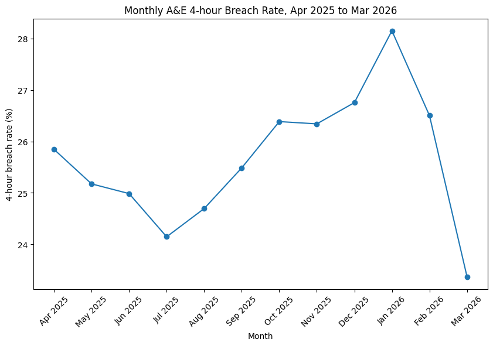

```python
plt.figure(figsize=(10, 6))

plt.plot(
    monthly_summary["period_month"],
    monthly_summary["four_hour_breach_rate"],
    marker="o"
)

plt.xlabel("Month")
plt.ylabel("4-hour breach rate (%)")
plt.title("Monthly A&E 4-hour Breach Rate, Apr 2025 to Mar 2026")

plt.xticks(rotation=45)

plt.show()
```

```python
monthly_summary["four_hour_breach_rate"] = monthly_summary["four_hour_breach_rate"].round(2)
monthly_summary["four_hour_performance_rate"] = monthly_summary["four_hour_performance_rate"].round(2)

monthly_summary
```

|  | period_date | total_ae_attendances | total_attendances_over_4hrs | four_hour_breach_rate | four_hour_performance_rate | period_month |
| --- | --- | --- | --- | --- | --- | --- |
| 0 | 2025-04-01 | 2209687 | 571127 | 25.85 | 74.15 | Apr 2025 |
| 1 | 2025-05-01 | 2309298 | 581375 | 25.18 | 74.82 | May 2025 |
| 2 | 2025-06-01 | 2268166 | 566734 | 24.99 | 75.01 | Jun 2025 |
| 3 | 2025-07-01 | 2320374 | 560285 | 24.15 | 75.85 | Jul 2025 |
| 4 | 2025-08-01 | 2182723 | 539040 | 24.70 | 75.30 | Aug 2025 |
| 5 | 2025-09-01 | 2227502 | 567723 | 25.49 | 74.51 | Sep 2025 |
| 6 | 2025-10-01 | 2314177 | 610640 | 26.39 | 73.61 | Oct 2025 |
| 7 | 2025-11-01 | 2261926 | 595846 | 26.34 | 73.66 | Nov 2025 |
| 8 | 2025-12-01 | 2240325 | 599421 | 26.76 | 73.24 | Dec 2025 |
| 9 | 2026-01-01 | 2235959 | 629487 | 28.15 | 71.85 | Jan 2026 |
| 10 | 2026-02-01 | 4087144 | 1083270 | 26.50 | 73.50 | Feb 2026 |
| 11 | 2026-03-01 | 2351317 | 549529 | 23.37 | 76.63 | Mar 2026 |

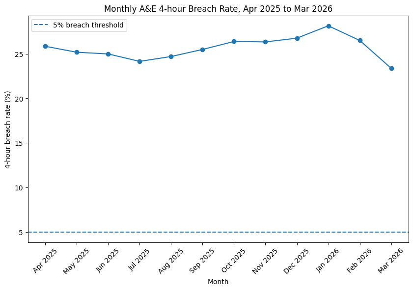

```python
plt.figure(figsize=(10, 6))

plt.plot(
    monthly_summary["period_month"],
    monthly_summary["four_hour_breach_rate"],
    marker="o"
)

plt.axhline(
    y=5,
    linestyle="--",
    label="5% breach threshold"
)

plt.xlabel("Month")
plt.ylabel("4-hour breach rate (%)")
plt.title("Monthly A&E 4-hour Breach Rate, Apr 2025 to Mar 2026")

plt.xticks(rotation=45)
plt.legend()
plt.show()
```

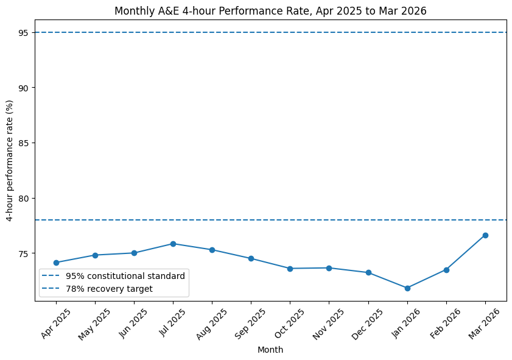

```python
plt.figure(figsize=(10, 6))

plt.plot(
    monthly_summary["period_month"],
    monthly_summary["four_hour_performance_rate"],
    marker="o"
)

plt.axhline(
    y=95,
    linestyle="--",
    label="95% constitutional standard"
)

plt.axhline(
    y=78,
    linestyle="--",
    label="78% recovery target"
)

plt.xlabel("Month")
plt.ylabel("4-hour performance rate (%)")
plt.title("Monthly A&E 4-hour Performance Rate, Apr 2025 to Mar 2026")

plt.xticks(rotation=45)
plt.legend()
plt.show()
```

### Initial interpretation: 12-month A&E performance trend

This chart shows the monthly A&E 4-hour performance rate from April 2025 to March 2026.

The performance rate represents the percentage of A&E attendances that were not recorded as waiting over 4 hours. A higher value indicates better performance, while a lower value suggests greater pressure on emergency care services.

The 95% reference line represents the historical constitutional standard for A&E 4-hour performance. The 78% reference line provides a more recent recovery benchmark used in operational planning. Comparing the monthly trend against both lines helps show how far current performance is from long-term expectations and recent recovery aims.

This trend analysis is useful because NHS England publishes A&E attendances and emergency admissions monthly, including attendances across A&E types, 4-hour performance and waits after decision to admit.

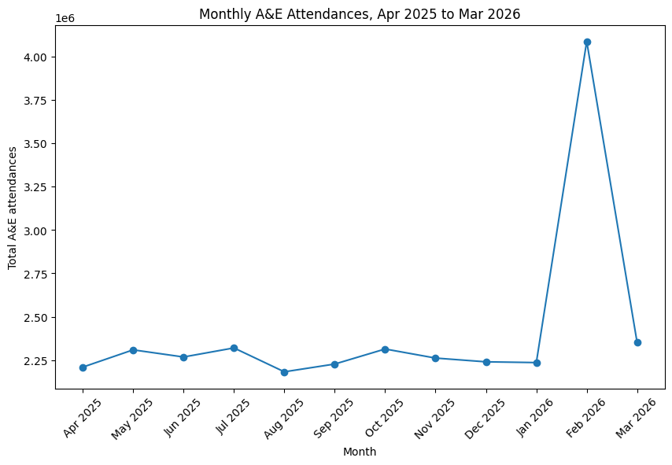

```python
plt.figure(figsize=(10, 6))

plt.plot(
    monthly_summary["period_month"],
    monthly_summary["total_ae_attendances"],
    marker="o"
)

plt.xlabel("Month")
plt.ylabel("Total A&E attendances")
plt.title("Monthly A&E Attendances, Apr 2025 to Mar 2026")

plt.xticks(rotation=45)
plt.show()
```

### Monthly A&E attendance trend

This chart shows total A&E attendances by month from April 2025 to March 2026.

This helps show whether changes in 4-hour performance may be linked to changes in demand. If attendances rise while performance falls, this may suggest that higher demand is contributing to pressure on emergency care services.

This analysis uses monthly NHS England A&E data across all A&E department types.

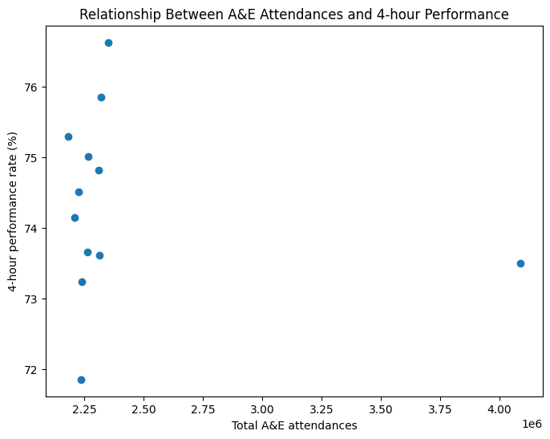

```python
plt.figure(figsize=(8, 6))

plt.scatter(
    monthly_summary["total_ae_attendances"],
    monthly_summary["four_hour_performance_rate"]
)

plt.xlabel("Total A&E attendances")
plt.ylabel("4-hour performance rate (%)")
plt.title("Relationship Between A&E Attendances and 4-hour Performance")

plt.show()
```

### Relationship between A&E attendances and 4-hour performance

This scatter plot compares total monthly A&E attendances with the 4-hour performance rate.

Each point represents one month. The purpose is to explore whether months with higher A&E demand also show lower 4-hour performance.

This does not prove that higher attendances directly caused lower performance, because A&E waiting times can also be affected by staffing levels, bed availability, discharge delays, case complexity and wider hospital flow. However, it provides an early view of whether demand pressure may be linked to performance changes.

```python
attendance_performance_correlation = monthly_summary[
    ["total_ae_attendances", "four_hour_performance_rate"]
].corr()

attendance_performance_correlation
```

|  | total_ae_attendances | four_hour_performance_rate |
| --- | --- | --- |
| total_ae_attendances | 1.000000 | -0.165822 |
| four_hour_performance_rate | -0.165822 | 1.000000 |

### Correlation between A&E attendances and 4-hour performance

The correlation between total monthly A&E attendances and 4-hour performance rate was -0.17.

This indicates a weak negative relationship. In this dataset, months with higher total A&E attendances were slightly associated with lower 4-hour performance, but the relationship was not strong.

This means demand may be one factor linked to performance pressure, but it is unlikely to explain the full picture on its own. Other operational factors such as staffing, bed availability, discharge delays, case mix and wider hospital flow may also affect A&E waiting times.

For this reason, the result should be treated as exploratory rather than causal.

```python
provider_summary = ae_clean.groupby("org_name").agg({
    "total_ae_attendances": "sum",
    "total_attendances_over_4hrs": "sum"
}).reset_index()

provider_summary["average_four_hour_breach_rate"] = (
    provider_summary["total_attendances_over_4hrs"] / provider_summary["total_ae_attendances"]
) * 100

provider_summary["average_four_hour_performance_rate"] = (
    100 - provider_summary["average_four_hour_breach_rate"]
)

provider_summary = provider_summary.sort_values(
    "average_four_hour_performance_rate",
    ascending=True
)

provider_summary.head(10)
```

|  | org_name | total_ae_attendances | total_attendances_over_4hrs | average_four_hour_breach_rate | average_four_hour_performance_rate |
| --- | --- | --- | --- | --- | --- |
| 42 | EAST CHESHIRE NHS TRUST | 53202 | 28236 | 53.073193 | 46.926807 |
| 176 | THE SHREWSBURY AND TELFORD HOSPITAL NHS TRUST | 160372 | 76983 | 48.002769 | 51.997231 |
| 141 | ROYAL UNITED HOSPITALS BATH NHS FOUNDATION TRUST | 107136 | 44929 | 41.936417 | 58.063583 |
| 70 | HULL UNIVERSITY TEACHING HOSPITALS NHS TRUST | 169370 | 69778 | 41.198559 | 58.801441 |
| 119 | NOTTINGHAM UNIVERSITY HOSPITALS NHS TRUST | 233327 | 95477 | 40.919825 | 59.080175 |
| 202 | WIRRAL UNIVERSITY TEACHING HOSPITAL NHS FOUNDA... | 129342 | 52034 | 40.229778 | 59.770222 |
| 101 | MID CHESHIRE HOSPITALS NHS FOUNDATION TRUST | 120332 | 48189 | 40.046704 | 59.953296 |
| 162 | SURREY AND SUSSEX HEALTHCARE NHS TRUST | 127380 | 50172 | 39.387659 | 60.612341 |
| 29 | COUNTESS OF CHESTER HOSPITAL NHS FOUNDATION TRUST | 92778 | 35799 | 38.585656 | 61.414344 |
| 164 | TAMESIDE AND GLOSSOP INTEGRATED CARE NHS FOUND... | 134368 | 51199 | 38.103566 | 61.896434 |

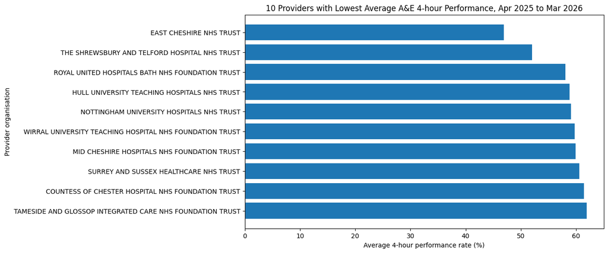

```python
bottom_10_providers = provider_summary.head(10)

plt.figure(figsize=(10, 6))

plt.barh(
    bottom_10_providers["org_name"],
    bottom_10_providers["average_four_hour_performance_rate"]
)

plt.xlabel("Average 4-hour performance rate (%)")
plt.ylabel("Provider organisation")
plt.title("10 Providers with Lowest Average A&E 4-hour Performance, Apr 2025 to Mar 2026")

plt.gca().invert_yaxis()

plt.show()
```

### Providers with the lowest average 4-hour performance

This chart shows the 10 provider organisations with the lowest average A&E 4-hour performance rate across the 12-month period.

The calculation uses total attendances and total attendances over 4 hours across the full year, rather than looking at a single month. This gives a more stable view of provider-level performance.

This analysis should be interpreted carefully. Lower performance may reflect several factors, including emergency demand, acuity, bed availability, discharge delays, staffing, and wider patient flow across the hospital. The chart identifies where performance pressure appears highest, but it does not explain the cause on its own.

```python
provider_summary_filtered = provider_summary[
    provider_summary["total_ae_attendances"] >= 50000
]

provider_summary_filtered = provider_summary_filtered.sort_values(
    "average_four_hour_performance_rate",
    ascending=True
)

provider_summary_filtered.head(10)
```

|  | org_name | total_ae_attendances | total_attendances_over_4hrs | average_four_hour_breach_rate | average_four_hour_performance_rate |
| --- | --- | --- | --- | --- | --- |
| 42 | EAST CHESHIRE NHS TRUST | 53202 | 28236 | 53.073193 | 46.926807 |
| 176 | THE SHREWSBURY AND TELFORD HOSPITAL NHS TRUST | 160372 | 76983 | 48.002769 | 51.997231 |
| 141 | ROYAL UNITED HOSPITALS BATH NHS FOUNDATION TRUST | 107136 | 44929 | 41.936417 | 58.063583 |
| 70 | HULL UNIVERSITY TEACHING HOSPITALS NHS TRUST | 169370 | 69778 | 41.198559 | 58.801441 |
| 119 | NOTTINGHAM UNIVERSITY HOSPITALS NHS TRUST | 233327 | 95477 | 40.919825 | 59.080175 |
| 202 | WIRRAL UNIVERSITY TEACHING HOSPITAL NHS FOUNDA... | 129342 | 52034 | 40.229778 | 59.770222 |
| 101 | MID CHESHIRE HOSPITALS NHS FOUNDATION TRUST | 120332 | 48189 | 40.046704 | 59.953296 |
| 162 | SURREY AND SUSSEX HEALTHCARE NHS TRUST | 127380 | 50172 | 39.387659 | 60.612341 |
| 29 | COUNTESS OF CHESTER HOSPITAL NHS FOUNDATION TRUST | 92778 | 35799 | 38.585656 | 61.414344 |
| 164 | TAMESIDE AND GLOSSOP INTEGRATED CARE NHS FOUND... | 134368 | 51199 | 38.103566 | 61.896434 |

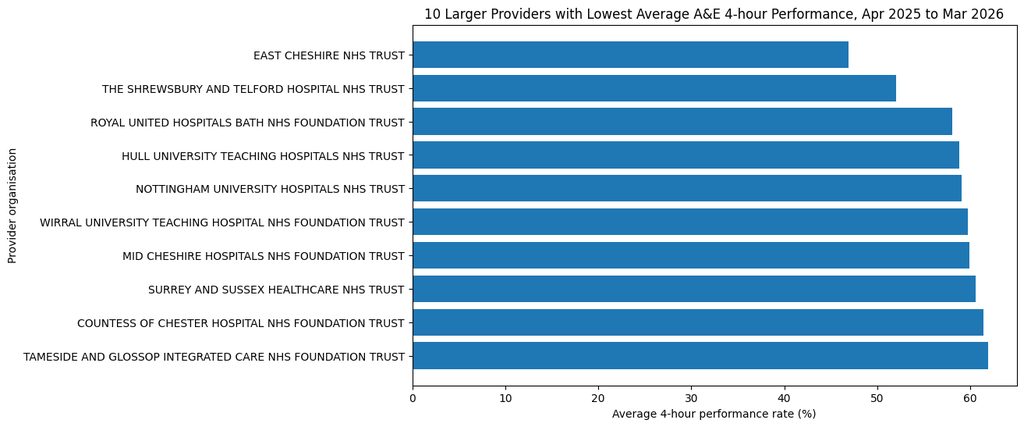

```python
bottom_10_filtered_providers = provider_summary_filtered.head(10)

plt.figure(figsize=(10, 6))

plt.barh(
    bottom_10_filtered_providers["org_name"],
    bottom_10_filtered_providers["average_four_hour_performance_rate"]
)

plt.xlabel("Average 4-hour performance rate (%)")
plt.ylabel("Provider organisation")
plt.title("10 Larger Providers with Lowest Average A&E 4-hour Performance, Apr 2025 to Mar 2026")

plt.gca().invert_yaxis()

plt.show()
```

### Larger providers with the lowest average 4-hour performance

This chart shows the 10 larger provider organisations with the lowest average A&E 4-hour performance rate across the 12-month period.

A minimum attendance threshold of 50,000 attendances across the year was used to reduce the effect of very small providers. This makes the comparison more meaningful because very small services can show extreme percentages due to lower activity volumes.

The results should still be interpreted carefully. Lower performance may reflect a combination of demand, acuity, bed availability, discharge delays, staffing levels and wider hospital flow.

```python
[column for column in ae_clean.columns if "dta" in column]
```

```
['patients_who_have_waited_4_12_hs_from_dta_to_admission',
 'patients_who_have_waited_12plus_hrs_from_dta_to_admission']
```

```python
ae_clean["total_dta_waits_over_4hrs"] = (
    ae_clean["patients_who_have_waited_4_12_hs_from_dta_to_admission"] +
    ae_clean["patients_who_have_waited_12plus_hrs_from_dta_to_admission"]
)

ae_clean[[
    "period_month",
    "org_name",
    "patients_who_have_waited_4_12_hs_from_dta_to_admission",
    "patients_who_have_waited_12plus_hrs_from_dta_to_admission",
    "total_dta_waits_over_4hrs"
]].head()
```

|  | period_month | org_name | patients_who_have_waited_4_12_hs_from_dta_to_admission | patients_who_have_waited_12plus_hrs_from_dta_to_admission | total_dta_waits_over_4hrs |
| --- | --- | --- | --- | --- | --- |
| 0 | Apr 2025 | FIRST COMMUNITY HEALTH AND CARE CIC | 0 | 0 | 0 |
| 1 | Apr 2025 | ASHFORD WALK-IN-CENTRE | 0 | 0 | 0 |
| 2 | Apr 2025 | WOKING WALK IN CENTRE | 0 | 0 | 0 |
| 3 | Apr 2025 | SOUTH BIRMINGHAM GP WALK IN CENTRE | 0 | 0 | 0 |
| 4 | Apr 2025 | PHL LYMINGTON UTC | 0 | 0 | 0 |

```python
monthly_dta_summary = ae_clean.groupby("period_date").agg({
    "patients_who_have_waited_4_12_hs_from_dta_to_admission": "sum",
    "patients_who_have_waited_12plus_hrs_from_dta_to_admission": "sum",
    "total_dta_waits_over_4hrs": "sum"
}).reset_index()

monthly_dta_summary["period_month"] = monthly_dta_summary["period_date"].dt.strftime("%b %Y")

monthly_dta_summary = monthly_dta_summary.sort_values("period_date")

monthly_dta_summary
```

|  | period_date | patients_who_have_waited_4_12_hs_from_dta_to_admission | patients_who_have_waited_12plus_hrs_from_dta_to_admission | total_dta_waits_over_4hrs | period_month |
| --- | --- | --- | --- | --- | --- |
| 0 | 2025-04-01 | 87208 | 44648 | 131856 | Apr 2025 |
| 1 | 2025-05-01 | 87144 | 42891 | 130035 | May 2025 |
| 2 | 2025-06-01 | 79488 | 38683 | 118171 | Jun 2025 |
| 3 | 2025-07-01 | 80075 | 35467 | 115542 | Jul 2025 |
| 4 | 2025-08-01 | 79917 | 35909 | 115826 | Aug 2025 |
| 5 | 2025-09-01 | 84239 | 44765 | 129004 | Sep 2025 |
| 6 | 2025-10-01 | 88420 | 54314 | 142734 | Oct 2025 |
| 7 | 2025-11-01 | 83151 | 50648 | 133799 | Nov 2025 |
| 8 | 2025-12-01 | 86988 | 50775 | 137763 | Dec 2025 |
| 9 | 2026-01-01 | 89624 | 71517 | 161141 | Jan 2026 |
| 10 | 2026-02-01 | 155178 | 109298 | 264476 | Feb 2026 |
| 11 | 2026-03-01 | 77205 | 46665 | 123870 | Mar 2026 |

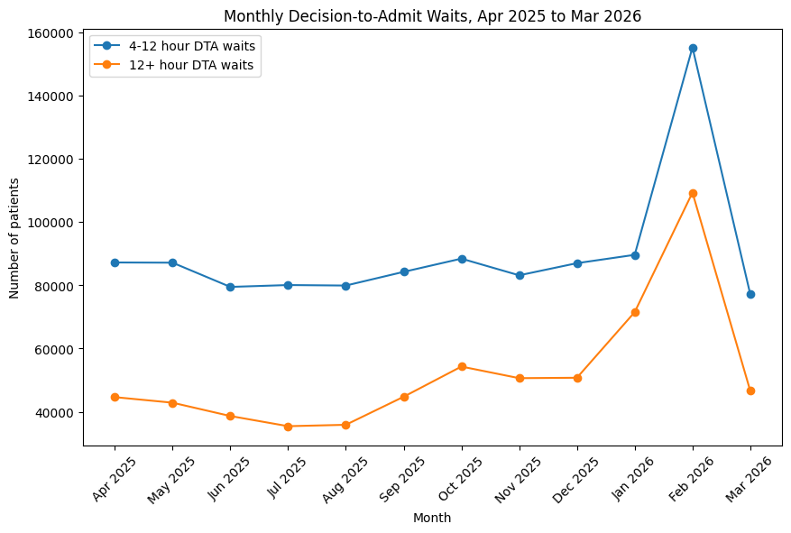

```python
plt.figure(figsize=(10, 6))

plt.plot(
    monthly_dta_summary["period_month"],
    monthly_dta_summary["patients_who_have_waited_4_12_hs_from_dta_to_admission"],
    marker="o",
    label="4-12 hour DTA waits"
)

plt.plot(
    monthly_dta_summary["period_month"],
    monthly_dta_summary["patients_who_have_waited_12plus_hrs_from_dta_to_admission"],
    marker="o",
    label="12+ hour DTA waits"
)

plt.xlabel("Month")
plt.ylabel("Number of patients")
plt.title("Monthly Decision-to-Admit Waits, Apr 2025 to Mar 2026")

plt.xticks(rotation=45)
plt.legend()
plt.show()
```

### Monthly decision-to-admit waits

This chart shows monthly decision-to-admit waits from April 2025 to March 2026.

Decision-to-admit waits measure patients who had already been assessed and had a decision made to admit them, but were still waiting for admission to hospital. This is different from the overall A&E 4-hour performance measure because it focuses specifically on admitted patients waiting after the decision to admit.

The chart separates 4-12 hour waits and 12+ hour waits. The 12+ hour waits are particularly important because they may indicate severe pressure in hospital flow, bed availability and discharge capacity.

This analysis is useful because it moves beyond overall A&E attendance numbers and looks at a more specific patient-flow pressure point.

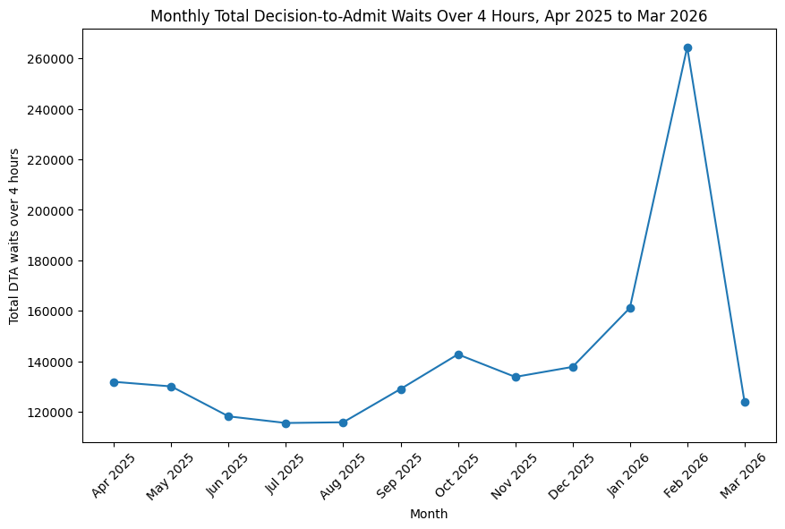

```python
plt.figure(figsize=(10, 6))

plt.plot(
    monthly_dta_summary["period_month"],
    monthly_dta_summary["total_dta_waits_over_4hrs"],
    marker="o"
)

plt.xlabel("Month")
plt.ylabel("Total DTA waits over 4 hours")
plt.title("Monthly Total Decision-to-Admit Waits Over 4 Hours, Apr 2025 to Mar 2026")

plt.xticks(rotation=45)
plt.show()
```

### Total decision-to-admit waits over 4 hours

This chart shows the total number of patients who waited more than 4 hours after a decision had been made to admit them.

This is an important patient-flow measure because these patients had already been assessed and needed admission, but were still waiting for a bed or suitable admission pathway.

A rising number of DTA waits may suggest pressure beyond the emergency department itself, including bed availability, discharge capacity, inpatient flow and wider hospital demand.

This does not prove the exact cause of the waits, but it helps identify months where admitted-patient flow pressure was higher.

```python
provider_dta_summary = ae_clean.groupby("org_name").agg({
    "patients_who_have_waited_4_12_hs_from_dta_to_admission": "sum",
    "patients_who_have_waited_12plus_hrs_from_dta_to_admission": "sum",
    "total_dta_waits_over_4hrs": "sum",
    "total_ae_attendances": "sum"
}).reset_index()

provider_dta_summary = provider_dta_summary[
    provider_dta_summary["org_name"] != "TOTAL"
]

provider_dta_summary = provider_dta_summary.sort_values(
    "patients_who_have_waited_12plus_hrs_from_dta_to_admission",
    ascending=False
)

provider_dta_summary.head(10)
```

|  | org_name | patients_who_have_waited_4_12_hs_from_dta_to_admission | patients_who_have_waited_12plus_hrs_from_dta_to_admission | total_dta_waits_over_4hrs | total_ae_attendances |
| --- | --- | --- | --- | --- | --- |
| 137 | ROYAL FREE LONDON NHS FOUNDATION TRUST | 12491 | 22650 | 35141 | 507130 |
| 184 | UNIVERSITY HOSPITALS BIRMINGHAM NHS FOUNDATION... | 32451 | 21023 | 53474 | 450266 |
| 176 | THE SHREWSBURY AND TELFORD HOSPITAL NHS TRUST | 5746 | 16915 | 22661 | 160372 |
| 43 | EAST KENT HOSPITALS UNIVERSITY NHS FOUNDATION ... | 5913 | 14153 | 20066 | 307425 |
| 115 | NORTHERN CARE ALLIANCE NHS FOUNDATION TRUST | 12557 | 13870 | 26427 | 425375 |
| 181 | UNITED LINCOLNSHIRE TEACHING HOSPITALS NHS TRUST | 10799 | 13254 | 24053 | 253436 |
| 9 | BARTS HEALTH NHS TRUST | 13320 | 12837 | 26157 | 534304 |
| 44 | EAST LANCASHIRE HOSPITALS NHS TRUST | 5452 | 12747 | 18199 | 294870 |
| 204 | WORCESTERSHIRE ACUTE HOSPITALS NHS TRUST | 11098 | 12165 | 23263 | 234375 |
| 85 | LIVERPOOL UNIVERSITY HOSPITALS NHS FOUNDATION ... | 16522 | 11762 | 28284 | 308985 |

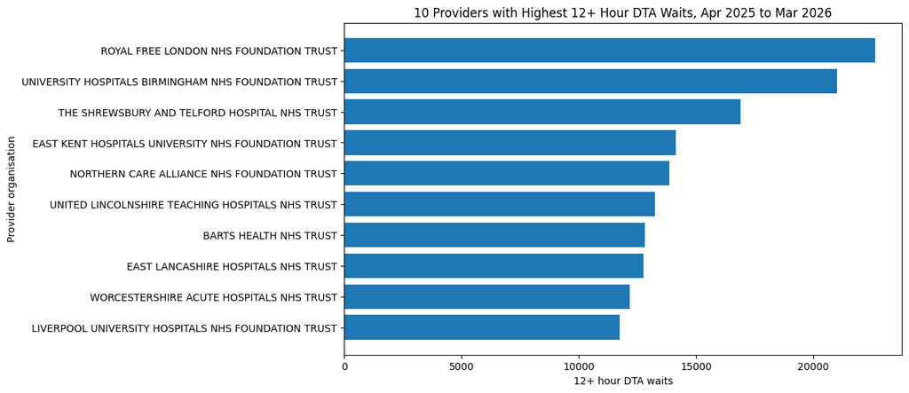

```python
top_10_dta_12hr_providers = provider_dta_summary.head(10)

plt.figure(figsize=(10, 6))

plt.barh(
    top_10_dta_12hr_providers["org_name"],
    top_10_dta_12hr_providers["patients_who_have_waited_12plus_hrs_from_dta_to_admission"]
)

plt.xlabel("12+ hour DTA waits")
plt.ylabel("Provider organisation")
plt.title("10 Providers with Highest 12+ Hour DTA Waits, Apr 2025 to Mar 2026")

plt.gca().invert_yaxis()

plt.show()
```

### Providers with the highest 12+ hour decision-to-admit waits

This chart shows the 10 provider organisations with the highest number of 12+ hour decision-to-admit waits across the 12-month period.

Decision-to-admit waits measure patients who had already been assessed and had a decision made to admit them, but were still waiting for admission. The 12+ hour category is particularly important because it indicates more severe admitted-patient flow pressure.

This chart uses absolute patient counts, so larger providers may naturally appear higher. The results should be interpreted alongside attendance volume, hospital size, bed availability, discharge capacity and wider system pressure.

```python
provider_dta_summary["dta_12hr_waits_per_1000_attendances"] = (
    provider_dta_summary["patients_who_have_waited_12plus_hrs_from_dta_to_admission"] /
    provider_dta_summary["total_ae_attendances"]
) * 1000

provider_dta_summary_rate = provider_dta_summary[
    provider_dta_summary["total_ae_attendances"] >= 50000
].sort_values(
    "dta_12hr_waits_per_1000_attendances",
    ascending=False
)

provider_dta_summary_rate.head(10)
```

|  | org_name | patients_who_have_waited_4_12_hs_from_dta_to_admission | patients_who_have_waited_12plus_hrs_from_dta_to_admission | total_dta_waits_over_4hrs | total_ae_attendances | dta_12hr_waits_per_1000_attendances |
| --- | --- | --- | --- | --- | --- | --- |
| 176 | THE SHREWSBURY AND TELFORD HOSPITAL NHS TRUST | 5746 | 16915 | 22661 | 160372 | 105.473524 |
| 196 | WARRINGTON AND HALTON TEACHING HOSPITALS NHS F... | 7893 | 10072 | 17965 | 118419 | 85.053919 |
| 29 | COUNTESS OF CHESTER HOSPITAL NHS FOUNDATION TRUST | 4735 | 7784 | 12519 | 92778 | 83.899200 |
| 42 | EAST CHESHIRE NHS TRUST | 2566 | 4105 | 6671 | 53202 | 77.158753 |
| 202 | WIRRAL UNIVERSITY TEACHING HOSPITAL NHS FOUNDA... | 6310 | 9311 | 15621 | 129342 | 71.987444 |
| 127 | PORTSMOUTH HOSPITALS UNIVERSITY NHS TRUST | 10092 | 11685 | 21777 | 176501 | 66.203591 |
| 49 | EPSOM AND ST HELIER UNIVERSITY HOSPITALS NHS T... | 7771 | 9944 | 17715 | 158195 | 62.859130 |
| 162 | SURREY AND SUSSEX HEALTHCARE NHS TRUST | 6482 | 7748 | 14230 | 127380 | 60.825875 |
| 114 | NORTHAMPTON GENERAL HOSPITAL NHS TRUST | 6683 | 8672 | 15355 | 157573 | 55.034809 |
| 101 | MID CHESHIRE HOSPITALS NHS FOUNDATION TRUST | 5881 | 6447 | 12328 | 120332 | 53.576771 |

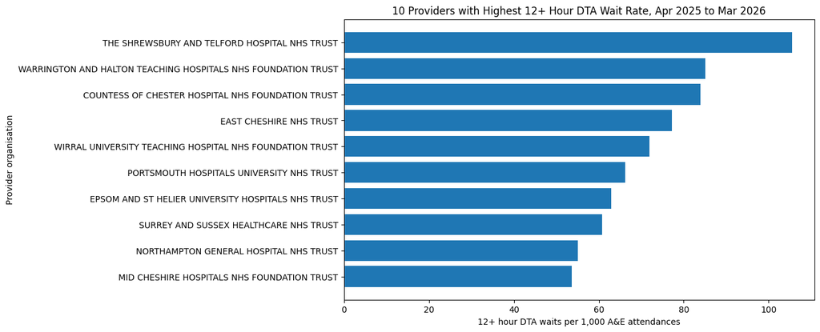

```python
top_10_dta_rate_providers = provider_dta_summary_rate.head(10)

plt.figure(figsize=(10, 6))

plt.barh(
    top_10_dta_rate_providers["org_name"],
    top_10_dta_rate_providers["dta_12hr_waits_per_1000_attendances"]
)

plt.xlabel("12+ hour DTA waits per 1,000 A&E attendances")
plt.ylabel("Provider organisation")
plt.title("10 Providers with Highest 12+ Hour DTA Wait Rate, Apr 2025 to Mar 2026")

plt.gca().invert_yaxis()

plt.show()
```

### Providers with the highest 12+ hour DTA wait rate

This chart shows the 10 larger provider organisations with the highest rate of 12+ hour decision-to-admit waits per 1,000 A&E attendances.

This is a fairer comparison than using raw counts alone because it accounts for provider size. A large hospital may naturally have more 12+ hour DTA waits simply because it sees more patients. By calculating the rate per 1,000 attendances, we can identify providers where long DTA waits appear high relative to overall A&E activity.

A minimum threshold of 50,000 attendances across the year was used to reduce distortion from very small providers.

This measure should still be interpreted carefully. High rates may reflect bed availability, discharge delays, patient acuity, staffing levels, local demand, or wider system flow challenges.

```python
ae_clean.to_csv("C:/Users/raahu/OneDrive/Desktop/nhs-ae-patient-flow-analysis/data_cleaned/ae_12_months_cleaned.csv", index=False)

monthly_summary.to_csv("C:/Users/raahu/OneDrive/Desktop/nhs-ae-patient-flow-analysis/outputs/monthly_ae_summary.csv", index=False)

provider_summary_filtered.to_csv("C:/Users/raahu/OneDrive/Desktop/nhs-ae-patient-flow-analysis/outputs/provider_ae_performance_summary.csv", index=False)

monthly_dta_summary.to_csv("C:/Users/raahu/OneDrive/Desktop/nhs-ae-patient-flow-analysis/outputs/monthly_dta_summary.csv", index=False)

provider_dta_summary_rate.to_csv("C:/Users/raahu/OneDrive/Desktop/nhs-ae-patient-flow-analysis/outputs/provider_dta_wait_rate_summary.csv", index=False)
```

```python
provider_dta_summary.to_csv("C:/Users/raahu/OneDrive/Desktop/nhs-ae-patient-flow-analysis/outputs/provider_dta_summary.csv",index=False)
```